# Compagny Bankrupcy

### Contexte :

Les entreprises sont confrontées à divers risques financiers, et la faillite est une des issues les plus graves qui peut résulter d'une gestion financière inadéquate. Les institutions financières, les investisseurs et les gestionnaires d'entreprises ont besoin de méthodes robustes pour évaluer la santé financière d'une entreprise et prédire les risques de faillite avant qu'ils ne se matérialisent. Avec la montée en puissance de l'analyse des données et des techniques de machine learning, il est possible d'utiliser des données financières historiques pour prédire avec précision les risques de faillite.

### Problématique:

#### Comment prédire la probabilité de faillite d'une entreprise en utilisant des données financières historiques pour améliorer les décisions de gestion et de prévention des risques ?

### Questions clefs du projet :

Quelles sont les variables financières les plus prédictives de la faillite ?

Comment les déséquilibres de classe dans les données affectent-ils la performance du modèle, et quelles techniques peuvent être utilisées pour les gérer ?

Comment les résultats du modèle peuvent-ils être utilisés pour améliorer la gestion des risques et la prise de décision dans les institutions financières et les entreprises ?

### Import des librairies

```python
import pandas as pd
import numpy as np
import matplotlib.pyplot as plt
import seaborn as sns

from sklearn.decomposition import PCA
from sklearn.preprocessing import StandardScaler
from sklearn.model_selection import RandomizedSearchCV, GridSearchCV, train_test_split
from sklearn.metrics import confusion_matrix, roc_auc_score, roc_curve, classification_report, ConfusionMatrixDisplay
from sklearn.linear_model import LogisticRegression
from sklearn.tree import DecisionTreeClassifier
from sklearn.neural_network import MLPClassifier
from skimpy import skim
from imblearn.over_sampling import SMOTE
import warnings

# Suppress all warnings
warnings.filterwarnings('ignore')
```

```python
df = pd.read_csv(r"C:\Users\devin\OneDrive\Bureau\SUJET PF preselection\Company Bankruptcy Prediction\data.csv")
```

## Exploration

```python
df.head()
```

|  | Bankrupt? | ROA(C) before interest and depreciation before interest | ROA(A) before interest and % after tax | ROA(B) before interest and depreciation after tax | Operating Gross Margin | Realized Sales Gross Margin | Operating Profit Rate | Pre-tax net Interest Rate | After-tax net Interest Rate | Non-industry income and expenditure/revenue | ... | Net Income to Total Assets | Total assets to GNP price | No-credit Interval | Gross Profit to Sales | Net Income to Stockholder's Equity | Liability to Equity | Degree of Financial Leverage (DFL) | Interest Coverage Ratio (Interest expense to EBIT) | Net Income Flag | Equity to Liability |
| --- | --- | --- | --- | --- | --- | --- | --- | --- | --- | --- | --- | --- | --- | --- | --- | --- | --- | --- | --- | --- | --- |
| 0 | 1 | 0.370594 | 0.424389 | 0.405750 | 0.601457 | 0.601457 | 0.998969 | 0.796887 | 0.808809 | 0.302646 | ... | 0.716845 | 0.009219 | 0.622879 | 0.601453 | 0.827890 | 0.290202 | 0.026601 | 0.564050 | 1 | 0.016469 |
| 1 | 1 | 0.464291 | 0.538214 | 0.516730 | 0.610235 | 0.610235 | 0.998946 | 0.797380 | 0.809301 | 0.303556 | ... | 0.795297 | 0.008323 | 0.623652 | 0.610237 | 0.839969 | 0.283846 | 0.264577 | 0.570175 | 1 | 0.020794 |
| 2 | 1 | 0.426071 | 0.499019 | 0.472295 | 0.601450 | 0.601364 | 0.998857 | 0.796403 | 0.808388 | 0.302035 | ... | 0.774670 | 0.040003 | 0.623841 | 0.601449 | 0.836774 | 0.290189 | 0.026555 | 0.563706 | 1 | 0.016474 |
| 3 | 1 | 0.399844 | 0.451265 | 0.457733 | 0.583541 | 0.583541 | 0.998700 | 0.796967 | 0.808966 | 0.303350 | ... | 0.739555 | 0.003252 | 0.622929 | 0.583538 | 0.834697 | 0.281721 | 0.026697 | 0.564663 | 1 | 0.023982 |
| 4 | 1 | 0.465022 | 0.538432 | 0.522298 | 0.598783 | 0.598783 | 0.998973 | 0.797366 | 0.809304 | 0.303475 | ... | 0.795016 | 0.003878 | 0.623521 | 0.598782 | 0.839973 | 0.278514 | 0.024752 | 0.575617 | 1 | 0.035490 |

5 rows × 96 columns

```python
skim(df)
```

```
╭──────────────────────────────────────────────── skimpy summary ─────────────────────────────────────────────────╮
│          Data Summary                Data Types                                                                 │
│ ┏━━━━━━━━━━━━━━━━━━━┳━━━━━━━━┓ ┏━━━━━━━━━━━━━┳━━━━━━━┓                                                          │
│ ┃ dataframe         ┃ Values ┃ ┃ Column Type ┃ Count ┃                                                          │
│ ┡━━━━━━━━━━━━━━━━━━━╇━━━━━━━━┩ ┡━━━━━━━━━━━━━╇━━━━━━━┩                                                          │
│ │ Number of rows    │ 6819   │ │ float64     │ 93    │                                                          │
│ │ Number of columns │ 96     │ │ int32       │ 3     │                                                          │
│ └───────────────────┴────────┘ └─────────────┴───────┘                                                          │
│                                                     number                                                      │
│ ┏━━━━━━━━━━━┳━━━━┳━━━━━━┳━━━━━━━━━━━┳━━━━━━━━━━━┳━━━━┳━━━━━━━━━━━┳━━━━━━━━━━━┳━━━━━━━━━━┳━━━━━━━━━━━┳━━━━━━━━┓  │
│ ┃ column_na ┃    ┃      ┃           ┃           ┃    ┃           ┃           ┃          ┃           ┃        ┃  │
│ ┃ me        ┃ NA ┃ NA % ┃ mean      ┃ sd        ┃ p0 ┃ p25       ┃ p50       ┃ p75      ┃ p100      ┃ hist   ┃  │
│ ┡━━━━━━━━━━━╇━━━━╇━━━━━━╇━━━━━━━━━━━╇━━━━━━━━━━━╇━━━━╇━━━━━━━━━━━╇━━━━━━━━━━━╇━━━━━━━━━━╇━━━━━━━━━━━╇━━━━━━━━┩  │
│ │ Bankrupt? │  0 │    0 │   0.03226 │    0.1767 │  0 │         0 │         0 │        0 │         1 │   ▇    │  │
│ │  ROA(C)   │  0 │    0 │    0.5052 │   0.06069 │  0 │    0.4765 │    0.5027 │   0.5356 │         1 │    ▇▇  │  │
│ │ before    │    │      │           │           │    │           │           │          │           │        │  │
│ │ interest  │    │      │           │           │    │           │           │          │           │        │  │
│ │ and       │    │      │           │           │    │           │           │          │           │        │  │
│ │ depreciat │    │      │           │           │    │           │           │          │           │        │  │
│ │ ion       │    │      │           │           │    │           │           │          │           │        │  │
│ │ before    │    │      │           │           │    │           │           │          │           │        │  │
│ │ interest  │    │      │           │           │    │           │           │          │           │        │  │
│ │  ROA(A)   │  0 │    0 │    0.5586 │   0.06562 │  0 │    0.5355 │    0.5598 │   0.5892 │         1 │    ▁▇  │  │
│ │ before    │    │      │           │           │    │           │           │          │           │        │  │
│ │ interest  │    │      │           │           │    │           │           │          │           │        │  │
│ │ and %     │    │      │           │           │    │           │           │          │           │        │  │
│ │ after tax │    │      │           │           │    │           │           │          │           │        │  │
│ │  ROA(B)   │  0 │    0 │    0.5536 │   0.06159 │  0 │    0.5273 │    0.5523 │   0.5841 │         1 │    ▁▇  │  │
│ │ before    │    │      │           │           │    │           │           │          │           │        │  │
│ │ interest  │    │      │           │           │    │           │           │          │           │        │  │
│ │ and       │    │      │           │           │    │           │           │          │           │        │  │
│ │ depreciat │    │      │           │           │    │           │           │          │           │        │  │
│ │ ion after │    │      │           │           │    │           │           │          │           │        │  │
│ │ tax       │    │      │           │           │    │           │           │          │           │        │  │
│ │  Operatin │  0 │    0 │    0.6079 │   0.01693 │  0 │    0.6004 │     0.606 │   0.6139 │         1 │     ▇  │  │
│ │ g Gross   │    │      │           │           │    │           │           │          │           │        │  │
│ │ Margin    │    │      │           │           │    │           │           │          │           │        │  │
│ │  Realized │  0 │    0 │    0.6079 │   0.01692 │  0 │    0.6004 │     0.606 │   0.6138 │         1 │     ▇  │  │
│ │ Sales     │    │      │           │           │    │           │           │          │           │        │  │
│ │ Gross     │    │      │           │           │    │           │           │          │           │        │  │
```

[output cut: 336 more lines]

```
│ │ (DFL)     │    │      │           │           │    │           │           │          │           │        │  │
│ │  Interest │  0 │    0 │    0.5654 │   0.01321 │  0 │    0.5652 │    0.5653 │   0.5657 │         1 │     ▇  │  │
│ │ Coverage  │    │      │           │           │    │           │           │          │           │        │  │
│ │ Ratio     │    │      │           │           │    │           │           │          │           │        │  │
│ │ (Interest │    │      │           │           │    │           │           │          │           │        │  │
│ │ expense   │    │      │           │           │    │           │           │          │           │        │  │
│ │ to EBIT)  │    │      │           │           │    │           │           │          │           │        │  │
│ │  Net      │  0 │    0 │         1 │  1.11e-16 │  1 │         1 │         1 │        1 │         1 │     ▇  │  │
│ │ Income    │    │      │           │           │    │           │           │          │           │        │  │
│ │ Flag      │    │      │           │           │    │           │           │          │           │        │  │
│ │  Equity   │  0 │    0 │   0.04758 │   0.05001 │  0 │   0.02448 │    0.0338 │  0.05284 │         1 │   ▇    │  │
│ │ to        │    │      │           │           │    │           │           │          │           │        │  │
│ │ Liability │    │      │           │           │    │           │           │          │           │        │  │
│ └───────────┴────┴──────┴───────────┴───────────┴────┴───────────┴───────────┴──────────┴───────────┴────────┘  │
╰────────────────────────────────────────────────────── End ──────────────────────────────────────────────────────╯
```

```python
df.shape
```

```
(6819, 96)
```

```python
df.info()
```

```
<class 'pandas.core.frame.DataFrame'>
RangeIndex: 6819 entries, 0 to 6818
Data columns (total 96 columns):
 #   Column                                                    Non-Null Count  Dtype
---  ------                                                    --------------  -----
 0   Bankrupt?                                                 6819 non-null   int64
 1    ROA(C) before interest and depreciation before interest  6819 non-null   float64
 2    ROA(A) before interest and % after tax                   6819 non-null   float64
 3    ROA(B) before interest and depreciation after tax        6819 non-null   float64
 4    Operating Gross Margin                                   6819 non-null   float64
 5    Realized Sales Gross Margin                              6819 non-null   float64
 6    Operating Profit Rate                                    6819 non-null   float64
 7    Pre-tax net Interest Rate                                6819 non-null   float64
 8    After-tax net Interest Rate                              6819 non-null   float64
 9    Non-industry income and expenditure/revenue              6819 non-null   float64
```

[output cut: 88 more lines]

Le jeu de donnée ne comporte aucune valeur manquante ni doublons. Il ne comporte que des variables numériques.

Nous sommes ici face à un problème de classification.

```python
print('Nombre de doublons', df.duplicated().sum())
print('Nombre de valeurs manquantes', df.isnull().sum().sum())
```

```
Nombre de doublons 0
Nombre de valeurs manquantes 0
```

## Séparation des features et de la target

```python
X = df.drop('Bankrupt?', axis=1)
y = df['Bankrupt?']
```

## Heatmap pour visualiser les corrélations entre les variables (relations linéaires)

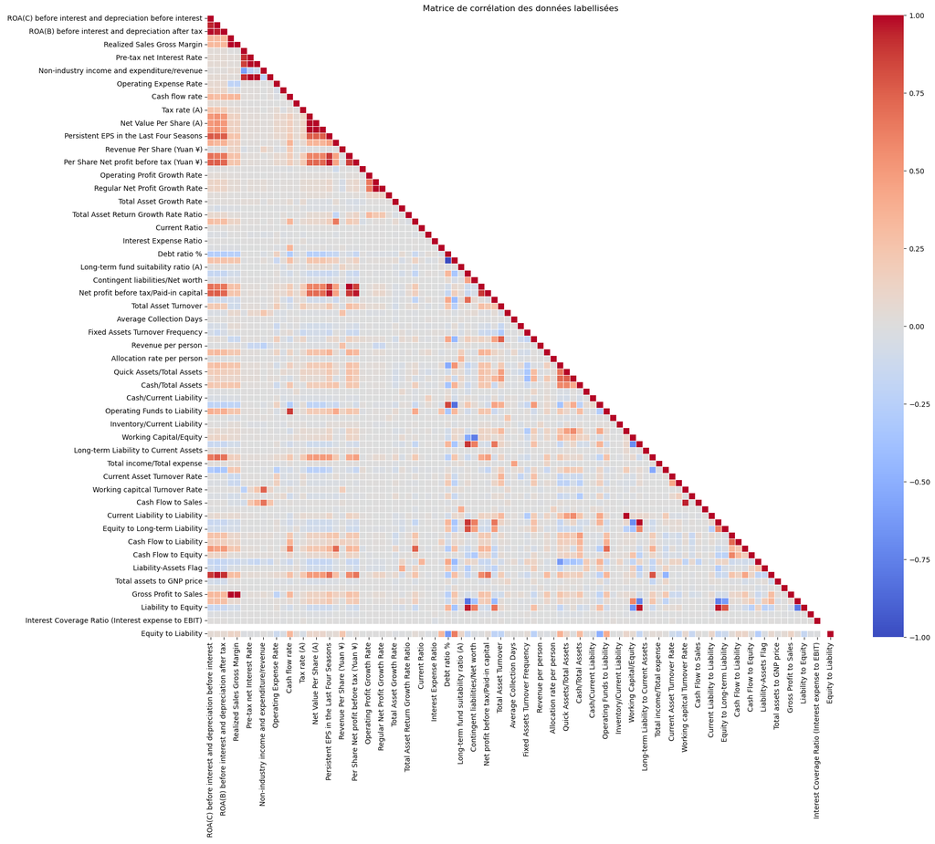

```python
def display_correlation_matrix(corr_matrix):
    plt.figure(figsize=(20, 16))
    sns.heatmap(corr_matrix, annot=False, cmap='coolwarm', linewidths=.5, mask=np.triu(corr_matrix, k=1))
    plt.title('Matrice de corrélation des données labellisées')
    plt.show()

corr_matrix = X.corr()
display_correlation_matrix(corr_matrix)
```

### Features X les plus corrélées positivement ou négativement

```python
corr_matrix = X.corr()
# On masque le triangle du haut pour une meilleure lisibilité:
mask = np.triu(np.ones_like(corr_matrix, dtype=bool), k=1)
triangle_sup = corr_matrix.where(mask).stack()

# On exclue les corrélations parfaites entre les variables elles même :
triangle_sup = triangle_sup[triangle_sup != 1]

print("Top 10 corrélations positives:")
print(triangle_sup.sort_values(ascending=False).head(10)) # Corrélation positives

print("\nTop 10 corrélations négatives:")
print(triangle_sup.sort_values(ascending=False).tail(10).sort_values(ascending=True))# Corrélation négatives
```

```
Top 10 corrélations positives:
 Operating Gross Margin                                    Gross Profit to Sales                                1.000000
 Net Value Per Share (A)                                   Net Value Per Share (C)                              0.999837
 Operating Gross Margin                                    Realized Sales Gross Margin                          0.999518
 Realized Sales Gross Margin                               Gross Profit to Sales                                0.999518
 Net Value Per Share (B)                                   Net Value Per Share (A)                              0.999342
                                                           Net Value Per Share (C)                              0.999179
 Operating Profit Per Share (Yuan ¥)                       Operating profit/Paid-in capital                     0.998696
 After-tax Net Profit Growth Rate                          Regular Net Profit Growth Rate                       0.996186
 Pre-tax net Interest Rate                                 Continuous interest rate (after tax)                 0.993617
 ROA(C) before interest and depreciation before interest   ROA(B) before interest and depreciation after tax    0.986849
dtype: float64

Top 10 corrélations négatives:
 Debt ratio %                         Net worth/Assets                     -1.000000
 Net worth/Assets                     Current Liability to Assets          -0.842583
 Borrowing dependency                 Net Income to Stockholder's Equity   -0.806478
 Net Income to Stockholder's Equity   Liability to Equity                  -0.791836
 Contingent liabilities/Net worth     Working Capital/Equity               -0.767778
 Current Liabilities/Equity           Net Income to Stockholder's Equity   -0.749621
 Current Liability to Equity          Net Income to Stockholder's Equity   -0.749621
 Working Capital/Equity               Current Liabilities/Equity           -0.692675
                                      Current Liability to Equity          -0.692675
                                      Liability to Equity                  -0.650474
dtype: float64
```

## Distribution de la variable cible

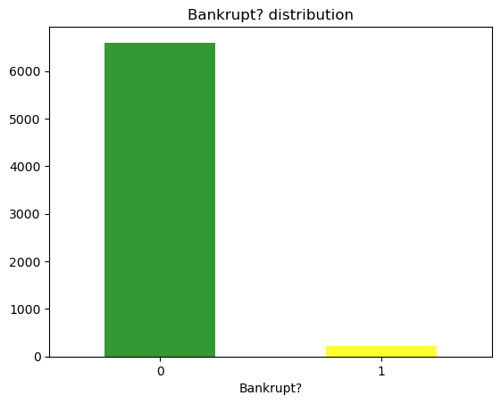

```
Nombre d'entreprise en faillite 220
Nombre d'entreprise qui ne sont pas en faillite 6599
Pourcentage d'entreprise en banqueroute 0.03
```

```python
y.value_counts().plot(kind='bar', title='Bankrupt? distribution', color=['green', 'yellow'], alpha=0.8, rot=1)
plt.show()

print("Nombre d'entreprise en faillite", y.value_counts()[1])
print("Nombre d'entreprise qui ne sont pas en faillite", y.value_counts()[0])
print("Pourcentage d'entreprise en banqueroute", (y.value_counts()[1] / y.value_counts()[0]).round(2),)
```

On voit que les données sont déséquilibrés en faveur des entreprises qui ne sont pas en faillite. Pour éviter que notre modèle ne fasse des prédictions biaisées dans la classe majoritaire, nous allons suréchantilloné la classe minoritaire.

```python
# Distribution de y avant suréchantillonage:

print("Avant SMOTE", y.value_counts())
print("Ratio d'entreprise en faillite:", y.value_counts()[1] / y.value_counts()[0])

smote = SMOTE(random_state=42)
X_smote, y_smote = smote.fit_resample(X, y)

# Application du SMOTE sur le train set
print("SMOTE train set:", y_smote.value_counts())
print("Ratio d'entreprise en faillite:", y_smote.value_counts()[1] / y_smote.value_counts()[0])
```

```
Avant SMOTE Bankrupt?
0    6599
1     220
Name: count, dtype: int64
Ratio d'entreprise en faillite: 0.03333838460372784
SMOTE train set: Bankrupt?
1    6599
0    6599
Name: count, dtype: int64
Ratio d'entreprise en faillite: 1.0
```

### Encodage de X

```python
scaler = StandardScaler()
X_scaled = scaler.fit_transform(X_smote)
```

### Hold Out

```python
X_train, X_test, y_train, y_test = train_test_split(X_scaled, y_smote, test_size=0.3, random_state=42)
```

## Analyse en composante principale PCA

```python
pca = PCA(n_components=0.90) # on conserve 90% de la variance

X_train_pca = pca.fit_transform(X_train)
X_test_pca = pca.transform(X_test)


Nombre_composantes = pca.n_components_

print('Nombre de composantes principales conservées:', Nombre_composantes)
ratio_variance_expliquée = pca.explained_variance_ratio_
ratio_variance_expliquée_cumulée = np.cumsum(ratio_variance_expliquée)
```

```
Nombre de composantes principales conservées: 42
```

Le ratio de variance expliqué exprime la proportion de variance capturée par chaque composante principale à partir des données. Le ratio de variance expliquée cumulée est l'accumulation du ratio de variance expliquée et peut être utilisé pour décider combien de composantes sont nécessaires.

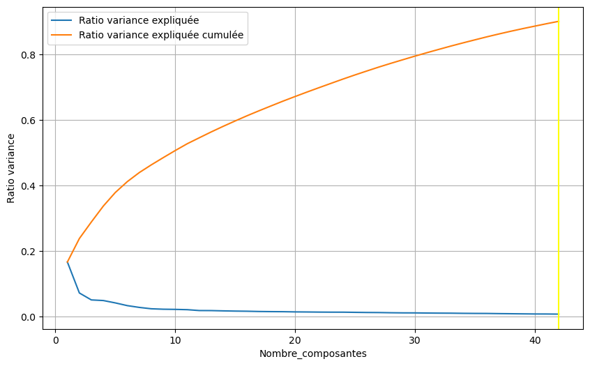

```python
plt.figure(figsize=(10, 6))

plt.plot(range(1, len(ratio_variance_expliquée) + 1), ratio_variance_expliquée, label="Ratio variance expliquée")
plt.plot(range(1, len(ratio_variance_expliquée_cumulée) + 1), ratio_variance_expliquée_cumulée,label="Ratio variance expliquée cumulée")

plt.axvline(Nombre_composantes, color="yellow", linestyle='-')
plt.xlabel("Nombre_composantes")
plt.ylabel("Ratio variance")
plt.legend()
plt.grid()
plt.show()
```

## Modèle de regression Logistique

```python
pca_initial_logreg = LogisticRegression(random_state=42)
```

```python
pca_initial_logreg.fit(X_train_pca, y_train)
```

```
LogisticRegression(random_state=42)
```

```python
pca_initial_logreg_test_score = pca_initial_logreg.score(X_test_pca, y_test)

print('PCA avec paramètres par défaut- Test score:', pca_initial_logreg_test_score)
```

```
PCA avec paramètres par défaut- Test score: 0.8893939393939394
```

## Recherche des meilleurs paramètres avec GridSearchCV

```python
param_grid = {
    'C': [0.001, 0.01, 0.1, 1, 10, 100], # Controle de la force de la régularisation
    'penalty': [None, 'l1', 'l2', 'elasticnet'], # type de régularisation (aucune, Ridge, lasso ou les deux : Elasticnet)
    'solver': ['liblinear', 'saga'],  # choix du solver qui optimise le mieux la fonction de cout
    'tol': [1e-4, 1e-3, 1e-2]}  # Tolerance pour les critères d'arret d'optimisation
```

```python
grid_search_pca_logreg = GridSearchCV(estimator=pca_initial_logreg, param_grid=param_grid, n_jobs=-1)

grid_search_pca_logreg.fit(X_train_pca, y_train)

best_params_pca_logreg = grid_search_pca_logreg.best_params_

print("Meilleurs paramètre PCA regression logistique:", best_params_pca_logreg)
```

```
Meilleurs paramètre PCA regression logistique: {'C': 0.1, 'penalty': 'l1', 'solver': 'liblinear', 'tol': 0.01}
```

```python
pca_logreg = LogisticRegression(**best_params_pca_logreg, random_state=42)

pca_logreg.fit(X_train_pca, y_train)

pca_logreg_test_score = pca_logreg.score(X_test_pca, y_test)

print("Meilleurs paramètres PCA - Test score:", pca_logreg_test_score)
```

```
Meilleurs paramètres PCA - Test score: 0.8881313131313131
```

```python
# Affichage des scores
print("PCA avec paramètres par défaut - Test score:", pca_initial_logreg_test_score)
print("PCA avec meilleurs paramètres - Test score:", pca_logreg_test_score)  # Assurez-vous que cette variable contient le score avec les meilleurs paramètres

# Comparaison des scores pour choisir le meilleur modèle
best_model = 'Optimisé' if pca_logreg_test_score > pca_initial_logreg_test_score else 'Par défaut'
print('The best model is:', best_model)
```

```
PCA avec paramètres par défaut - Test score: 0.8893939393939394
PCA avec meilleurs paramètres - Test score: 0.8881313131313131
The best model is: Par défaut
```

## Ensemble des métriques

```python
y_pred = grid_search_pca_logreg.predict(X_test_pca)
y_pred_proba = grid_search_pca_logreg.predict_proba(X_test_pca)[:, 1]
```

```
Matrice de confusion
               precision    recall  f1-score   support

           0       0.90      0.87      0.89      2005
           1       0.87      0.90      0.89      1955

    accuracy                           0.89      3960
   macro avg       0.89      0.89      0.89      3960
weighted avg       0.89      0.89      0.89      3960
```

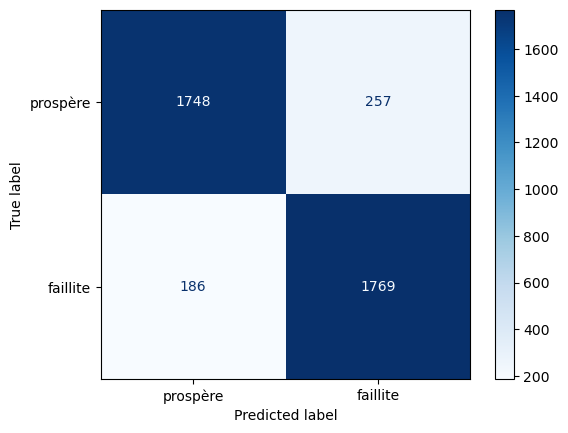

```python
# confusion matrix for the tuned model without PCA
conf_matrix = confusion_matrix(y_test, y_pred)

print("Matrice de confusion \n", classification_report(y_test, y_pred))

class_names = { 'prospère' : 0, 'faillite' : 1}

disp = ConfusionMatrixDisplay(confusion_matrix=conf_matrix, display_labels=class_names)
disp.plot(cmap='Blues')
plt.show()
```

## Rappel :

L'Accuracy (exactitude) est la proportion d'instances correctement classées par rapport au nombre total d'instances.

La précision (Precision) est la proportion de vraies prédictions positives parmi toutes les prédictions positives.

La sensibilité, également appelée taux de vrais positifs ou rappel (Recall), mesure la proportion de vrais positifs identifiés correctement par la prédiction.

La spécificité, également appelée taux de vrais négatifs (True Negative Rate), mesure la proportion de vrais négatifs identifiés correctement par la prédiction.

## Détail de la matrice de confusion

```python
tn, fp, fn, tp = conf_matrix.ravel()

accuracy = (tp + tn) / (tp + tn + fp + fn)
precision = tp / (tp + fp)
sensitivity = tp / (tp + fn)
specificity = tn / (tn + fp)

print("Vrais positifs:", tp, "Faux Positifs:", fp)
print("Vrais négatifs:", tn, "Faux négatifs:", fn)
print("\n")
print("Le modèle fait", tp + tn, "prédictions correctes et", fp + fn, "prédictions incorrectes")
print("Le modèle a correctement prédit", round(accuracy * 100, 2), '% des classements à effectuer.')
print("Le modèle a correctement prédit la faillite d'une entreprise dans", round(precision * 100, 2), "% des cas.")
print("\n")
print("L'accuracy est de:", accuracy)
print("La précision est de:", precision)
print("La sensibilité est de :", sensitivity)
print("La spécificité est de :", specificity)
```

```
Vrais positifs: 1769 Faux Positifs: 257
Vrais négatifs: 1748 Faux négatifs: 186


Le modèle fait 3517 prédictions correctes et 443 prédictions incorrectes
Le modèle a correctement prédit 88.81 % des classements à effectuer.
Le modèle a correctement prédit la faillite d'une entreprise dans 87.31 % des cas.


L'accuracy est de: 0.8881313131313131
La précision est de: 0.8731490621915103
La sensibilité est de : 0.9048593350383631
La spécificité est de : 0.8718204488778055
```

```python
#Calcul du f1-score
f1_score = 2 * (precision * sensitivity) / (precision + sensitivity)

print("Le F1 score est de:", f1_score)
```

```
Le F1 score est de: 0.8887214267771917
```

## Courbe ROC d'évaluation du modèle

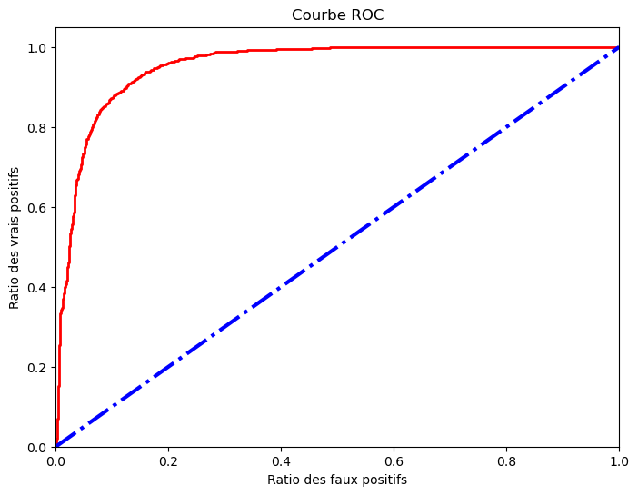

```python
fpr, tpr, thresholds = roc_curve(y_test, y_pred_proba)
auc = roc_auc_score(y_test, y_pred_proba)

plt.figure(figsize=(8, 6))

plt.plot(fpr, tpr, color='red', lw=2, label='ROC curve (area = %0.2f)' % auc)
plt.plot([0, 1], [0, 1], color='blue', lw=3, linestyle='-.')

plt.xlim([0.0, 1.0])
plt.ylim([0.0, 1.05])

plt.xlabel('Ratio des faux positifs')
plt.ylabel('Ratio des vrais positifs')
plt.title('Courbe ROC')
plt.show()
```